# Homework 11

Solutions will be available after Monday, November 9, 2026.

## Question 1: Implementing K-means

K-means is a relatively simple algorithm that we can write ourselves. For Questions 1 and 2, do not use an existing function that performs K-means directly.

Generate 10 observations with two independent standard normal coordinates. Set a random seed and report it. Randomly assign the observations to $K=2$ clusters, making sure neither cluster is empty. Let $C(i)$ denote the cluster assigned to observation $x_i$, and let $m_k$ denote the mean of cluster $k$.

1. Perform one iteration: calculate the cluster means, then assign each observation to its closest mean using Euclidean distance. Report the means and updated assignments, and plot the observations colored by their updated assignments.

```
Data seed: 42
Initial assignment seed: 10

Initial cluster means:
```

|  | x1 | x2 |
| --- | --- | --- |
| Cluster 1 | -0.367811 | -0.857587 |
| Cluster 2 | 0.557759 | 0.149399 |

```
Observations and assignments:
```

|  | Observation | x1 | x2 | Initial cluster | Updated cluster |
| --- | --- | --- | --- | --- | --- |
| 0 | 1 | 0.304717 | -1.039984 | 2 | 1 |
| 1 | 2 | 0.750451 | 0.940565 | 2 | 2 |
| 2 | 3 | -1.951035 | -1.302180 | 1 | 1 |
| 3 | 4 | 0.127840 | -0.316243 | 1 | 2 |
| 4 | 5 | -0.016801 | -0.853044 | 1 | 1 |
| 5 | 6 | 0.879398 | 0.777792 | 2 | 2 |
| 6 | 7 | 0.066031 | 1.127241 | 2 | 2 |
| 7 | 8 | 0.467509 | -0.859292 | 2 | 1 |
| 8 | 9 | 0.368751 | -0.958883 | 1 | 1 |
| 9 | 10 | 0.878450 | -0.049926 | 2 | 2 |

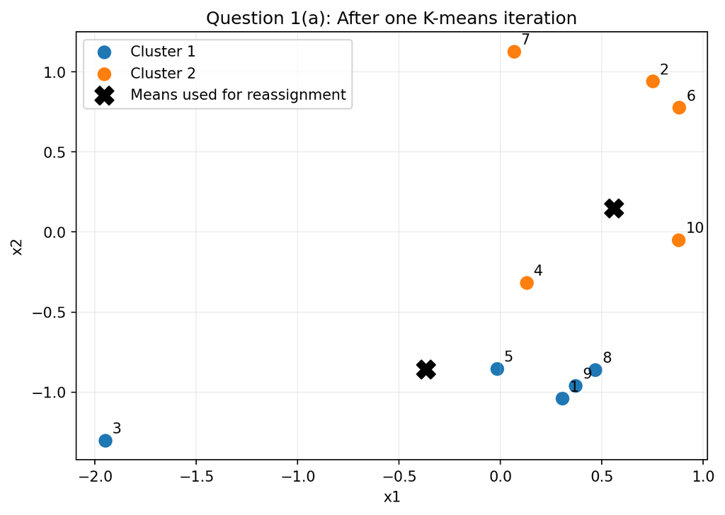

```python
import numpy as np
import pandas as pd
import matplotlib.pyplot as plt

# Generate 10 observations with two independent N(0, 1) coordinates
data_seed = 42
rng = np.random.default_rng(data_seed)
X = rng.normal(size=(10, 2))

# Random initial assignments, guaranteeing both clusters are nonempty
assignment_seed = 10
rng_assign = np.random.default_rng(assignment_seed)

initial_assignments = np.concatenate([
    np.arange(2),
    rng_assign.integers(0, 2, size=8)
])
rng_assign.shuffle(initial_assignments)

# Calculate means from the initial assignments
cluster_means = np.vstack([
    X[initial_assignments == k].mean(axis=0)
    for k in range(2)
])

# Calculate Euclidean distances and update assignments
distances = np.linalg.norm(
    X[:, None, :] - cluster_means[None, :, :],
    axis=2
)
updated_assignments = distances.argmin(axis=1)

print(f"Data seed: {data_seed}")
print(f"Initial assignment seed: {assignment_seed}")

print("\nInitial cluster means:")
display(pd.DataFrame(
    cluster_means,
    columns=["x1", "x2"],
    index=["Cluster 1", "Cluster 2"]
))

print("\nObservations and assignments:")
display(pd.DataFrame({
    "Observation": np.arange(1, 11),
    "x1": X[:, 0],
    "x2": X[:, 1],
    "Initial cluster": initial_assignments + 1,
    "Updated cluster": updated_assignments + 1
}))

# Plot observations using their updated assignments
plt.figure(figsize=(7, 5))

for k in range(2):
    members = updated_assignments == k
    plt.scatter(
        X[members, 0],
        X[members, 1],
        label=f"Cluster {k + 1}",
        s=70
    )

# These are the initial means used for this reassignment
plt.scatter(
    cluster_means[:, 0],
    cluster_means[:, 1],
    color="black",
    marker="X",
    s=160,
    label="Means used for reassignment"
)

for i, (x1, x2) in enumerate(X):
    plt.annotate(
        str(i + 1),
        (x1, x2),
        xytext=(5, 5),
        textcoords="offset points"
    )

plt.xlabel("x1")
plt.ylabel("x2")
plt.title("Question 1(a): After one K-means iteration")
plt.legend()
plt.grid(alpha=0.2)
plt.tight_layout()
plt.show()
```

2. Write a function that repeats these two steps until the assignments stop changing or a specified maximum number of iterations is reached. Your function should work for a data matrix with any number of variables and a chosen number of clusters $K$. Start from a nonempty assignment to each cluster; if a cluster becomes empty during iteration, keep its previous mean. Recalculate the cluster means from the final assignments before returning them. Return the final assignments, cluster means, and within-cluster sum of squares,

   $$\sum_{k=1}^K\sum_{i:\,C(i)=k}\lVert x_i-m_k\rVert^2.$$

```python
def custom_kmeans(X, K, initial_assignments=None, seed=0, max_iter=300):
    X = np.asarray(X, dtype=float)

    if X.ndim != 2 or min(X.shape) == 0:
        raise ValueError("X must be a nonempty data matrix.")

    if not np.isfinite(X).all():
        raise ValueError("X must contain only finite values.")

    n, p = X.shape

    if not isinstance(K, (int, np.integer)) or not 1 <= K <= n:
        raise ValueError("K must be an integer between 1 and n.")

    if not isinstance(max_iter, (int, np.integer)) or max_iter < 1:
        raise ValueError("max_iter must be a positive integer.")

    # Initialize assignments with every cluster represented
    if initial_assignments is None:
        rng = np.random.default_rng(seed)
        assignments = np.concatenate([
            np.arange(K),
            rng.integers(0, K, size=n - K)
        ])
        rng.shuffle(assignments)
    else:
        supplied = np.asarray(initial_assignments)

        if supplied.shape != (n,):
            raise ValueError("Provide one initial assignment per observation.")

        if not np.isin(supplied, np.arange(K)).all():
            raise ValueError("Cluster labels must be 0, ..., K-1.")

        assignments = supplied.astype(int).copy()

    if len(np.unique(assignments)) != K:
        raise ValueError("Every initial cluster must be nonempty.")

    means = np.vstack([
        X[assignments == k].mean(axis=0)
        for k in range(K)
    ])

    converged = False

    for iteration in range(1, max_iter + 1):
        # Update means; retain previous means for empty clusters
        for k in range(K):
            members = X[assignments == k]

            if len(members) > 0:
                means[k] = members.mean(axis=0)

        # Assign observations to their nearest mean
        squared_distances = (
            (X[:, None, :] - means[None, :, :]) ** 2
        ).sum(axis=2)

        new_assignments = squared_distances.argmin(axis=1)

        if np.array_equal(new_assignments, assignments):
            converged = True
            break

        assignments = new_assignments

    # Recalculate means from the final assignments
    for k in range(K):
        members = X[assignments == k]

        if len(members) > 0:
            means[k] = members.mean(axis=0)

    wcss = float(
        ((X - means[assignments]) ** 2).sum()
    )

    return {
        "assignments": assignments,
        "means": means,
        "wcss": wcss,
        "iterations": iteration,
        "converged": converged
    }
```

3. Apply your function to the same 10 observations from two different random initial assignments. Report the final plots, cluster means, and within-cluster sums of squares. Do the two runs produce the same grouping and objective value? Explain your findings.

```
Initial assignment seed: 10
WCSS: 5.982342
Converged: True
Final assignments: [1 2 1 1 1 2 2 1 1 2]
```

|  | x1 | x2 |
| --- | --- | --- |
| Cluster 1 | -0.116503 | -0.888271 |
| Cluster 2 | 0.643583 | 0.698918 |

```
Initial assignment seed: 20
WCSS: 5.982342
Converged: True
Final assignments: [1 2 1 1 1 2 2 1 1 2]
```

|  | x1 | x2 |
| --- | --- | --- |
| Cluster 1 | -0.116503 | -0.888271 |
| Cluster 2 | 0.643583 | 0.698918 |

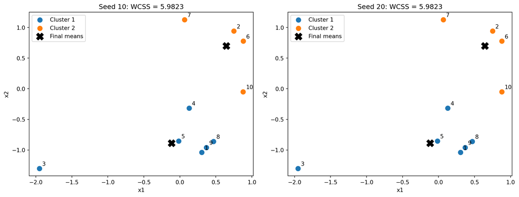

```
Same grouping: True
Same objective value: True
```

```python
initial_seeds = [10, 20]
results = []

fig, axes = plt.subplots(1, 2, figsize=(13, 5))

for ax, seed in zip(axes, initial_seeds):
    result = custom_kmeans(X, K=2, seed=seed)
    results.append(result)

    assignments = result["assignments"]
    means = result["means"]

    print(f"\nInitial assignment seed: {seed}")
    print(f"WCSS: {result['wcss']:.6f}")
    print(f"Converged: {result['converged']}")
    print("Final assignments:", assignments + 1)

    display(pd.DataFrame(
        means,
        columns=["x1", "x2"],
        index=["Cluster 1", "Cluster 2"]
    ))

    for k in range(2):
        members = assignments == k

        ax.scatter(
            X[members, 0],
            X[members, 1],
            label=f"Cluster {k + 1}",
            s=70
        )

    ax.scatter(
        means[:, 0],
        means[:, 1],
        color="black",
        marker="X",
        s=160,
        label="Final means"
    )

    for i, (x1, x2) in enumerate(X):
        ax.annotate(
            str(i + 1),
            (x1, x2),
            xytext=(5, 5),
            textcoords="offset points"
        )

    ax.set_title(f"Seed {seed}: WCSS = {result['wcss']:.4f}")
    ax.set_xlabel("x1")
    ax.set_ylabel("x2")
    ax.legend()

plt.tight_layout()
plt.show()

# Compare groupings while allowing cluster labels to switch
a = results[0]["assignments"]
b = results[1]["assignments"]

same_grouping = np.array_equal(
    a[:, None] == a[None, :],
    b[:, None] == b[None, :]
)

same_objective = np.isclose(
    results[0]["wcss"],
    results[1]["wcss"]
)

print("Same grouping:", same_grouping)
print("Same objective value:", same_objective)
```

Pick your favorite color image and use your K-means function from Question 1 to cluster its pixels. For computational efficiency, resize the image to no more than $200\times200$ pixels and use its three RGB color channels.

1. Plot the original image and report its dimensions. Transform it into a data matrix with one observation per pixel and three variables: red, green, and blue. Report the dimensions of this matrix.

```
Original dimensions (width, height): (512, 512)
Resized dimensions (height, width): (200, 200)
Pixel matrix dimensions: (40000, 3)
RGB scale: 0–255
```

[figure not shown]

```python
import numpy as np
import matplotlib.pyplot as plt
from PIL import Image
from skimage import data

# Built-in astronaut photograph; no local image file needed
image = Image.fromarray(data.astronaut()).convert("RGB")

print("Original dimensions (width, height):", image.size)

# Resize while preserving aspect ratio
image.thumbnail((200, 200), Image.Resampling.LANCZOS)

rgb = np.asarray(image, dtype=float)
height, width, channels = rgb.shape

# One observation per pixel; three variables: red, green, blue
pixels = rgb.reshape(-1, 3)

print("Resized dimensions (height, width):", (height, width))
print("Pixel matrix dimensions:", pixels.shape)
print("RGB scale: 0–255")

plt.figure(figsize=(6, 6))
plt.imshow(rgb.astype(np.uint8))
plt.title(f"Original colors: {width} × {height} pixels")
plt.axis("off")
plt.show()
```

2. For $K=2,3,5,10$, apply your function to the pixel data. Report the cluster means and within-cluster sum of squares for each $K$. Reconstruct and plot each compressed image by replacing every pixel with its assigned cluster mean. Use the same RGB scale for all fits.

```
K = 2
Selected seed: 101
WCSS: 228,633,432.14
Converged: True
```

| Cluster | Red | Green | Blue |
| --- | --- | --- | --- |
| 1 | 56.187045 | 25.494402 | 21.742172 |
| 2 | 197.361787 | 158.250672 | 145.379728 |

```
K = 3
Selected seed: 101
WCSS: 110,723,603.05
Converged: True
```

| Cluster | Red | Green | Blue |
| --- | --- | --- | --- |
| 1 | 35.410065 | 14.925226 | 15.686617 |
| 2 | 199.843206 | 188.813286 | 184.982922 |
| 3 | 179.126507 | 98.574108 | 72.769734 |

```
K = 5
Selected seed: 101
WCSS: 56,811,226.13
Converged: True
```

| Cluster | Red | Green | Blue |
| --- | --- | --- | --- |
| 1 | 208.560046 | 198.318801 | 194.798019 |
| 2 | 214.574474 | 100.630665 | 64.120147 |
| 3 | 157.738076 | 142.392413 | 136.808280 |
| 4 | 10.863182 | 5.593496 | 6.528571 |
| 5 | 103.636774 | 48.622931 | 41.876317 |

```
K = 10
Selected seed: 303
WCSS: 23,233,518.99
Converged: True
```

| Cluster | Red | Green | Blue |
| --- | --- | --- | --- |
| 1 | 224.874527 | 113.141491 | 77.131924 |
| 2 | 53.760148 | 34.380074 | 33.867159 |
| 3 | 181.276459 | 168.912725 | 163.285383 |
| 4 | 208.263094 | 197.057811 | 192.860226 |
| 5 | 122.061875 | 24.880861 | 19.837817 |
| 6 | 235.227805 | 229.583415 | 230.999512 |
| 7 | 5.262467 | 2.502003 | 2.318000 |
| 8 | 146.034577 | 129.120849 | 121.712427 |
| 9 | 194.129548 | 76.631758 | 38.985719 |
| 10 | 102.523004 | 83.470311 | 81.881243 |

```
Summary:
```

| K | WCSS | WCSS per pixel | Iterations | Converged |
| --- | --- | --- | --- | --- |
| 2 | 2.286334e+08 | 5715.835803 | 11 | True |
| 3 | 1.107236e+08 | 2768.090076 | 12 | True |
| 5 | 5.681123e+07 | 1420.280653 | 27 | True |
| 10 | 2.323352e+07 | 580.837975 | 69 | True |

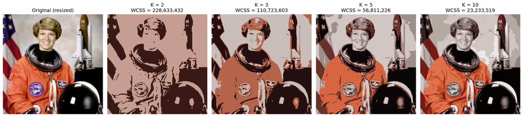

```python
K_values = [2, 3, 5, 10]
image_results = {}
summary_rows = []

for K in K_values:
    seeds = [101, 202, 303]

    fits = [
        custom_kmeans(
            pixels,
            K=K,
            seed=seed,
            max_iter=300
        )
        for seed in seeds
    ]

    best_index = int(np.argmin([fit["wcss"] for fit in fits]))
    best_fit = fits[best_index]

    image_results[K] = best_fit

    print(f"\nK = {K}")
    print(f"Selected seed: {seeds[best_index]}")
    print(f"WCSS: {best_fit['wcss']:,.2f}")
    print(f"Converged: {best_fit['converged']}")

    display(pd.DataFrame(
        best_fit["means"],
        columns=["Red", "Green", "Blue"],
        index=np.arange(1, K + 1)
    ).rename_axis("Cluster"))

    summary_rows.append({
        "K": K,
        "WCSS": best_fit["wcss"],
        "WCSS per pixel": best_fit["wcss"] / len(pixels),
        "Iterations": best_fit["iterations"],
        "Converged": best_fit["converged"]
    })

compression_summary = pd.DataFrame(summary_rows).set_index("K")

print("\nSummary:")
display(compression_summary)

# Reconstruct the images using cluster means
fig, axes = plt.subplots(1, 5, figsize=(18, 5))

axes[0].imshow(rgb.astype(np.uint8))
axes[0].set_title("Original (resized)")

for ax, K in zip(axes[1:], K_values):
    fit = image_results[K]

    compressed = fit["means"][fit["assignments"]].reshape(rgb.shape)

    # Round only for display; fitting and WCSS use floating point means
    compressed_display = np.clip(
        np.rint(compressed), 0, 255
    ).astype(np.uint8)

    ax.imshow(compressed_display)
    ax.set_title(f"K = {K}\nWCSS = {fit['wcss']:,.0f}")

for ax in axes:
    ax.axis("off")

plt.tight_layout()
plt.show()
```

3. Which value of $K$ would you choose for this image? Briefly justify your choice using the reconstructed images and the within-cluster sums of squares.

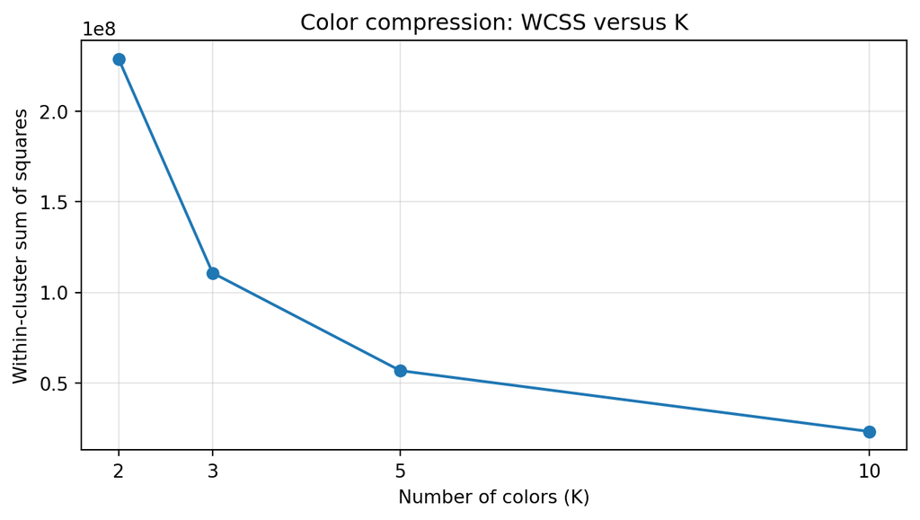

```
WCSS reduction from K=5 to K=10: 59.1%
```

```python
plt.figure(figsize=(7, 4))

plt.plot(
    compression_summary.index,
    compression_summary["WCSS"],
    marker="o"
)

plt.xticks(K_values)
plt.xlabel("Number of colors (K)")
plt.ylabel("Within-cluster sum of squares")
plt.title("Color compression: WCSS versus K")
plt.grid(alpha=0.3)
plt.tight_layout()
plt.show()

reduction = (
    1 - compression_summary.loc[10, "WCSS"]
    / compression_summary.loc[5, "WCSS"]
) * 100

print(f"WCSS reduction from K=5 to K=10: {reduction:.1f}%")
```

Choose the smallest K that preserves the details you consider important. If ten colors noticeably improve the image over five and substantially reduce WCSS, K = 10 is reasonable. If five colors already look satisfactory, K = 5 offers a smaller palette. Your justification should match the image you selected.

## Question 3: Hierarchical clustering of cars

The file `data/mtcars.csv` contains 11 numerical variables for 32 cars, including fuel economy, horsepower, and weight. The `car` column gives the model names; use it to label observations, not as a clustering variable. You may use existing hierarchical clustering functions for this question.

1. Standardize each numerical variable to have mean 0 and standard deviation 1. Using Euclidean distance, perform hierarchical clustering with single, complete, and average linkage. Plot the three dendrograms with the car names and compare the results.

```
Data dimensions: (32, 11)
```

|  | Standardized mean | Standardized SD |
| --- | --- | --- |
| mpg | -4.996004e-16 | 1.0 |
| cyl | -2.775558e-17 | 1.0 |
| disp | 1.110223e-16 | 1.0 |
| hp | 2.775558e-17 | 1.0 |
| drat | -3.053113e-16 | 1.0 |
| wt | -4.163336e-16 | 1.0 |
| qsec | -1.443290e-15 | 1.0 |
| vs | 0.000000e+00 | 1.0 |
| am | 5.551115e-17 | 1.0 |
| gear | -2.775558e-17 | 1.0 |
| carb | 2.775558e-17 | 1.0 |

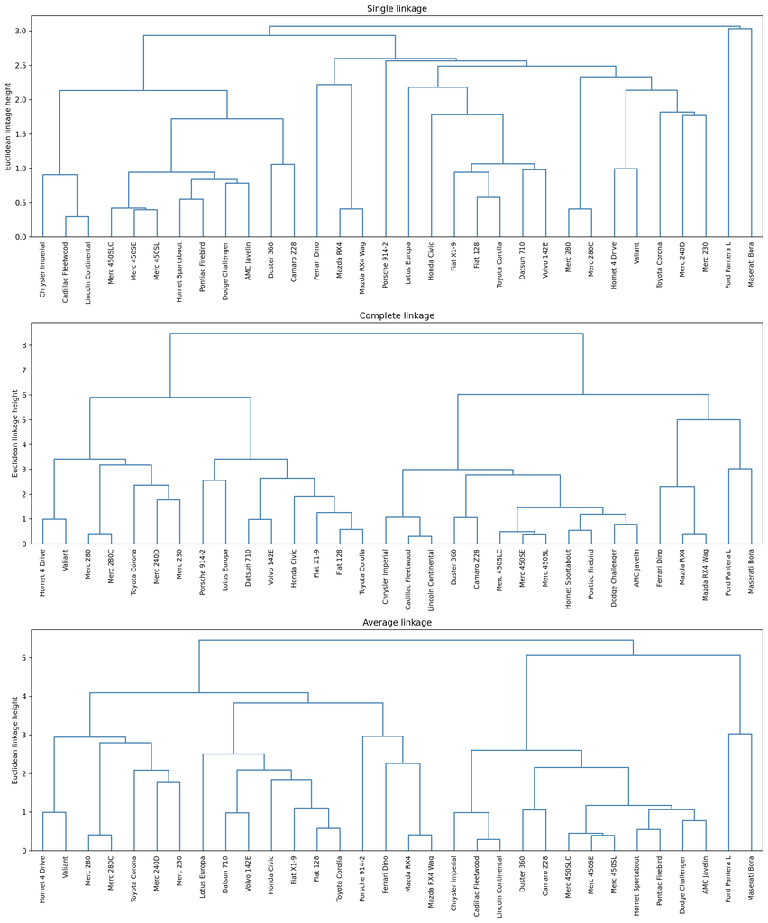

```python
from scipy.cluster.hierarchy import linkage, dendrogram, cut_tree

cars = pd.read_csv("data/mtcars.csv").set_index("car")

# Standardize each numerical variable using the sample SD
cars_standardized = (
    (cars - cars.mean()) / cars.std(ddof=1)
)

print("Data dimensions:", cars.shape)

display(pd.DataFrame({
    "Standardized mean": cars_standardized.mean(),
    "Standardized SD": cars_standardized.std(ddof=1)
}))

linkage_results = {}

fig, axes = plt.subplots(3, 1, figsize=(15, 18))

for ax, method in zip(axes, ["single", "complete", "average"]):
    tree = linkage(
        cars_standardized.to_numpy(),
        method=method,
        metric="euclidean"
    )

    linkage_results[method] = tree

    dendrogram(
        tree,
        labels=cars.index.tolist(),
        leaf_rotation=90,
        leaf_font_size=9,
        color_threshold=0,
        above_threshold_color="steelblue",
        ax=ax
    )

    ax.set_title(f"{method.capitalize()} linkage")
    ax.set_ylabel("Euclidean linkage height")

plt.tight_layout()
plt.show()
```

|  | Car | Cluster |
| --- | --- | --- |
| 0 | Ferrari Dino | 1 |
| 1 | Ford Pantera L | 1 |
| 2 | Maserati Bora | 1 |
| 3 | Mazda RX4 | 1 |
| 4 | Mazda RX4 Wag | 1 |
| 5 | Datsun 710 | 2 |
| 6 | Fiat 128 | 2 |
| 7 | Fiat X1-9 | 2 |
| 8 | Honda Civic | 2 |
| 9 | Hornet 4 Drive | 2 |
| 10 | Lotus Europa | 2 |
| 11 | Merc 230 | 2 |
| 12 | Merc 240D | 2 |
| 13 | Merc 280 | 2 |
| 14 | Merc 280C | 2 |
| 15 | Porsche 914-2 | 2 |
| 16 | Toyota Corolla | 2 |
| 17 | Toyota Corona | 2 |
| 18 | Valiant | 2 |
| 19 | Volvo 142E | 2 |
| 20 | AMC Javelin | 3 |
| 21 | Cadillac Fleetwood | 3 |
| 22 | Camaro Z28 | 3 |
| 23 | Chrysler Imperial | 3 |
| 24 | Dodge Challenger | 3 |
| 25 | Duster 360 | 3 |
| 26 | Hornet Sportabout | 3 |
| 27 | Lincoln Continental | 3 |
| 28 | Merc 450SE | 3 |
| 29 | Merc 450SL | 3 |
| 30 | Merc 450SLC | 3 |
| 31 | Pontiac Firebird | 3 |

```
Cluster 1:
Mazda RX4, Mazda RX4 Wag, Ford Pantera L, Ferrari Dino, Maserati Bora

Cluster 2:
Datsun 710, Hornet 4 Drive, Valiant, Merc 240D, Merc 230, Merc 280, Merc 280C, Fiat 128, Honda Civic, Toyota Corolla, Toyota Corona, Fiat X1-9, Porsche 914-2, Lotus Europa, Volvo 142E

Cluster 3:
Hornet Sportabout, Duster 360, Merc 450SE, Merc 450SL, Merc 450SLC, Cadillac Fleetwood, Lincoln Continental, Chrysler Imperial, Dodge Challenger, AMC Javelin, Camaro Z28, Pontiac Firebird

Cluster means on original scales:
```

| Cluster | Number of cars | mpg | cyl | disp | hp | drat | wt | qsec | vs | am | gear | carb |
| --- | --- | --- | --- | --- | --- | --- | --- | --- | --- | --- | --- | --- |
| 1 | 5 | 18.500000 | 6.800000 | 223.400000 | 198.800000 | 3.836000 | 3.001000 | 15.6160 | 0.000000 | 1.000000 | 4.600000 | 5.200000 |
| 2 | 15 | 24.653333 | 4.533333 | 131.646667 | 91.333333 | 3.897333 | 2.579867 | 19.1580 | 0.933333 | 0.533333 | 3.933333 | 1.800000 |
| 3 | 12 | 15.050000 | 8.000000 | 357.616667 | 194.166667 | 3.120833 | 4.104083 | 17.1425 | 0.000000 | 0.000000 | 3.000000 | 3.083333 |

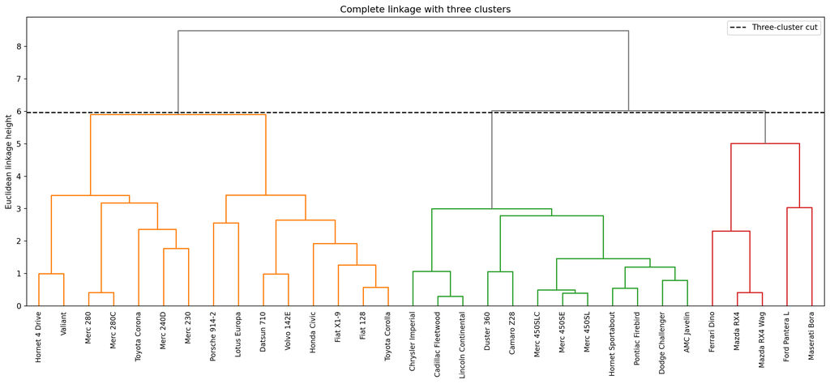

```python
# Choose complete linkage and three clusters
chosen_tree = linkage_results["complete"]
K_cars = 3

car_clusters = cut_tree(
    chosen_tree,
    n_clusters=K_cars
).ravel() + 1

# Report memberships
memberships = pd.DataFrame({
    "Car": cars.index,
    "Cluster": car_clusters
})

display(
    memberships.sort_values(["Cluster", "Car"]).reset_index(drop=True)
)

for k in range(1, K_cars + 1):
    print(f"\nCluster {k}:")
    print(", ".join(cars.index[car_clusters == k]))

# Calculate means on the ORIGINAL scales
cars_with_clusters = cars.assign(Cluster=car_clusters)

cluster_means_original = (
    cars_with_clusters.groupby("Cluster").mean()
)

cluster_sizes = cars_with_clusters.groupby("Cluster").size()
cluster_means_original.insert(0, "Number of cars", cluster_sizes)

print("\nCluster means on original scales:")
display(cluster_means_original)

# Place a horizontal line between the 4→3 and 3→2 merges
cut_height = (
    chosen_tree[-3, 2] + chosen_tree[-2, 2]
) / 2

plt.figure(figsize=(15, 7))

dendrogram(
    chosen_tree,
    labels=cars.index.tolist(),
    leaf_rotation=90,
    leaf_font_size=9,
    color_threshold=cut_height,
    above_threshold_color="gray"
)

plt.axhline(
    cut_height,
    color="black",
    linestyle="--",
    label="Three-cluster cut"
)

plt.title("Complete linkage with three clusters")
plt.ylabel("Euclidean linkage height")
plt.legend()
plt.tight_layout()
plt.show()
```

The three-cluster cut separates interpretable car types, although its narrow height interval means the dendrogram also supports considering two clusters. Standardization matters because variables have different units and ranges; without it, variables such as displacement and horsepower could dominate Euclidean distances.